# Happiness

Guannan Liu

11/6/2020

## What is this?

This is the project draft for CS510. This project was created in 2018 as the final of my first r course.

The happiness score is a sum of these factors and the higher the happiness rank, the higher the happiness score.

#### Load required packages

```r
packages <- c("tree", "gbm","randomForest","testthat","rmarkdown","MVN")

package.check <- lapply(
  packages,
  FUN <- function(x) {
    if (!require(x, character.only = TRUE)) {
      install.packages(x, dependencies = TRUE, repos='http://cran.us.r-project.org')
      library(x, character.only = TRUE)
    }
  }
)
```

#### import data

```r
dir()
```

```
## [1] "Happiness_Model.html" "Happiness_Model.r"    "Happiness_Model.Rmd"
```

```r
getwd() #To locate the source folder. Please set the scouse folder at src/, then it could read data automatically
```

```
## [1] "/Users/guannanliu/Desktop/Happiness/src"
```

```r
dat2015<- read.csv("../data/2015.csv")
dat2016 <- read.csv("../data/2016.csv")
dat2017 <- read.csv("../data/2017.csv")
dat2018 <- read.csv("../data/2018.csv")
dat2019 <- read.csv("../data/2019.csv")
```

#### clean data

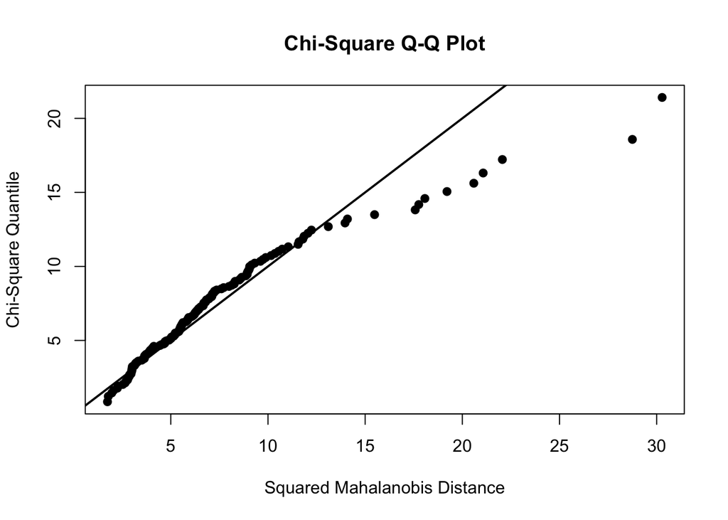

```
## $multivariateNormality
##            Test       HZ p value MVN
## 1 Henze-Zirkler 1.717563       0  NO
##
## $univariateNormality
##           Test                     Variable Statistic   p value Normality
## 1 Shapiro-Wilk            Score                0.9872  0.1633      YES
## 2 Shapiro-Wilk        GDP.per.capita           0.9653   6e-04      NO
## 3 Shapiro-Wilk        Social.support           0.9074  <0.001      NO
## 4 Shapiro-Wilk   Healthy.life.expectancy       0.9534  <0.001      NO
## 5 Shapiro-Wilk Freedom.to.make.life.choices    0.9543   1e-04      NO
## 6 Shapiro-Wilk          Generosity             0.9639   4e-04      NO
## 7 Shapiro-Wilk  Perceptions.of.corruption      0.8228  <0.001      NO
##
## $Descriptives
##                                n      Mean    Std.Dev Median   Min   Max
## Score                        156 5.4070962 1.11311987 5.3795 2.853 7.769
## GDP.per.capita               156 0.9051474 0.39838946 0.9600 0.000 1.684
## Social.support               156 1.2088141 0.29919140 1.2715 0.000 1.624
## Healthy.life.expectancy      156 0.7252436 0.24212400 0.7890 0.000 1.141
## Freedom.to.make.life.choices 156 0.3925705 0.14328947 0.4170 0.000 0.631
## Generosity                   156 0.1848462 0.09525444 0.1775 0.000 0.566
## Perceptions.of.corruption    156 0.1106026 0.09453784 0.0855 0.000 0.453
##                                 25th    75th       Skew   Kurtosis
## Score                        4.54450 6.18450  0.0112307 -0.6575891
## GDP.per.capita               0.60275 1.23250 -0.3778556 -0.8119864
## Social.support               1.05575 1.45250 -1.1129992  1.0986926
## Healthy.life.expectancy      0.54775 0.88175 -0.6020864 -0.3655918
## Freedom.to.make.life.choices 0.30800 0.50725 -0.6725067 -0.1418838
## Generosity                   0.10875 0.24825  0.7316579  1.0453403
## Perceptions.of.corruption    0.04700 0.14125  1.6188066  2.2340824
##
## $multivariateOutliers
## NULL
##
## $newData
## NULL
```

```r
dat1 = dat2019[,c(3:9)]  #delete unsless variable: Country.or.region, country and rank
dat1 = na.omit(dat1)
#check data
size=dim(dat1)
mvn(dat1,  mvnTest = "hz",
    univariatePlot = "qq", multivariatePlot = "qq",
    multivariateOutlierMethod = "none",
    showOutliers = TRUE, showNewData = TRUE) #Check the Multivariate & Univariate Normality
```

```r
cor(dat1)
```

```
##                                   Score GDP.per.capita Social.support
## Score                        1.00000000     0.79388287     0.77705779
## GDP.per.capita               0.79388287     1.00000000     0.75490573
## Social.support               0.77705779     0.75490573     1.00000000
## Healthy.life.expectancy      0.77988315     0.83546212     0.71900946
## Freedom.to.make.life.choices 0.56674183     0.37907907     0.44733316
## Generosity                   0.07582369    -0.07966231    -0.04812645
## Perceptions.of.corruption    0.38561307     0.29891985     0.18189946
##                              Healthy.life.expectancy
## Score                                     0.77988315
## GDP.per.capita                            0.83546212
## Social.support                            0.71900946
## Healthy.life.expectancy                   1.00000000
## Freedom.to.make.life.choices              0.39039478
## Generosity                               -0.02951086
## Perceptions.of.corruption                 0.29528281
##                              Freedom.to.make.life.choices  Generosity
## Score                                           0.5667418  0.07582369
## GDP.per.capita                                  0.3790791 -0.07966231
## Social.support                                  0.4473332 -0.04812645
## Healthy.life.expectancy                         0.3903948 -0.02951086
## Freedom.to.make.life.choices                    1.0000000  0.26974181
## Generosity                                      0.2697418  1.00000000
## Perceptions.of.corruption                       0.4388433  0.32653754
##                              Perceptions.of.corruption
## Score                                        0.3856131
## GDP.per.capita                               0.2989198
## Social.support                               0.1818995
## Healthy.life.expectancy                      0.2952828
## Freedom.to.make.life.choices                 0.4388433
## Generosity                                   0.3265375
## Perceptions.of.corruption                    1.0000000
```

This correlation analysis shows the GDP.per.capita is the most significant, Healthy.life.expectancy to make life choices is the second.

#### Create a training and test set to test for later use:

```r
set.seed(1)
train = sample(1:size[1],size[1]/2)
dat.train = dat1[train,]
set.seed(1)
dat1.other = dat1[-train,]
valid = sample(1:nrow(dat1.other),size[1]/2)
dat.valid = dat1.other[valid,]
dim(dat.train)
```

```
## [1] 78  7
```

```r
dim(dat.valid)
```

```
## [1] 78  7
```

## Part I:

### Continuous Dependent Variable - Look at the Happiness score

#### Elementary linear regression

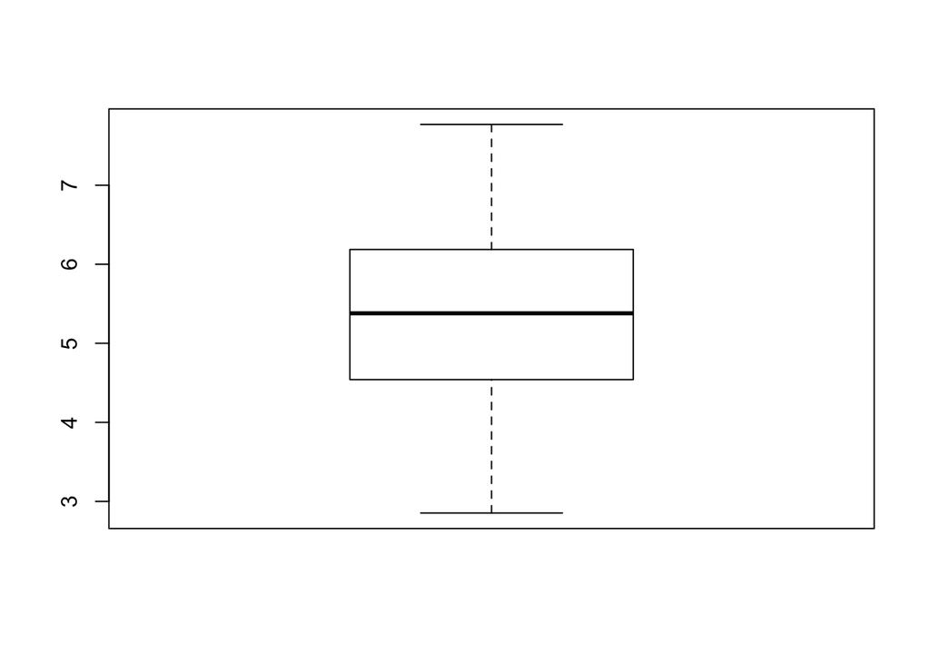

```r
reg1 = lm(Score~., data = dat1)
options(scipen = 999)
boxplot(dat1$Score)
```

```r
summary(reg1)
```

```
##
## Call:
## lm(formula = Score ~ ., data = dat1)
##
## Residuals:
##      Min       1Q   Median       3Q      Max
## -1.75304 -0.35306  0.05703  0.36695  1.19059
##
## Coefficients:
##                              Estimate Std. Error t value           Pr(>|t|)
## (Intercept)                    1.7952     0.2111   8.505 0.0000000000000177 ***
## GDP.per.capita                 0.7754     0.2182   3.553           0.000510 ***
## Social.support                 1.1242     0.2369   4.745 0.0000048338066976 ***
## Healthy.life.expectancy        1.0781     0.3345   3.223           0.001560 **
## Freedom.to.make.life.choices   1.4548     0.3753   3.876           0.000159 ***
## Generosity                     0.4898     0.4977   0.984           0.326709
## Perceptions.of.corruption      0.9723     0.5424   1.793           0.075053 .
## ---
## Signif. codes:  0 '***' 0.001 '**' 0.01 '*' 0.05 '.' 0.1 ' ' 1
##
## Residual standard error: 0.5335 on 149 degrees of freedom
## Multiple R-squared:  0.7792, Adjusted R-squared:  0.7703
## F-statistic: 87.62 on 6 and 149 DF,  p-value: < 0.00000000000000022
```

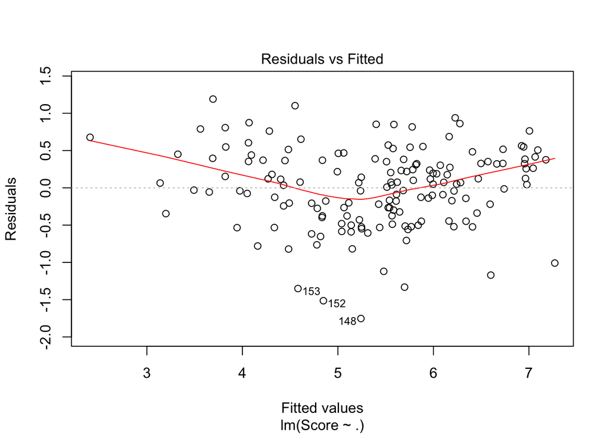

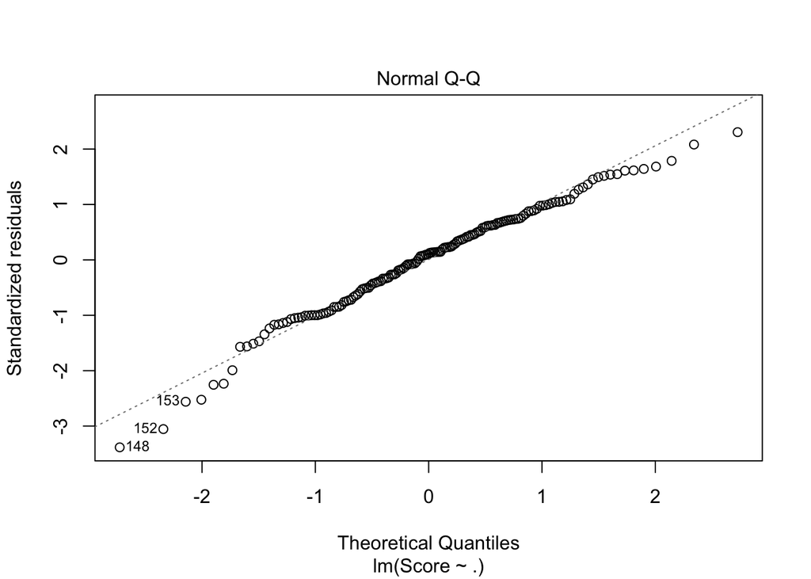

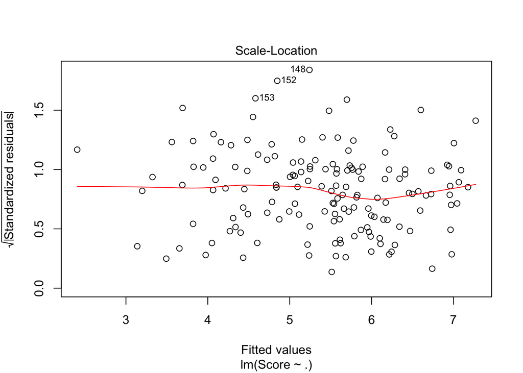

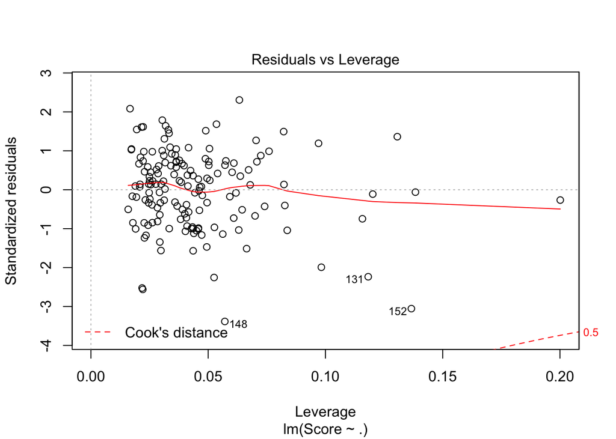

```r
plot(reg1)
```

```r
yhat.all = predict(reg1, dat1)
MSE.all = mean((dat1$Score-yhat.all)^2)
MSE.all
```

```
## [1] 0.27187
```

This linear model suggests GDP,SicialSUpport, freedom and LifeExpectancy is significant with a overall Adjusted R-squared: 0.7703 MSE is 0.27187

#### What about a small model, which only look at the top 2 factor

```r
reg2 <- lm(Score~Social.support+Freedom.to.make.life.choices, data = dat1)
anova(reg2, reg1, test = "Chisq")
```

```
## Analysis of Variance Table
##
## Model 1: Score ~ Social.support + Freedom.to.make.life.choices
## Model 2: Score ~ GDP.per.capita + Social.support + Healthy.life.expectancy +
##     Freedom.to.make.life.choices + Generosity + Perceptions.of.corruption
##   Res.Df    RSS Df Sum of Sq              Pr(>Chi)
## 1    153 64.557
## 2    149 42.412  4    22.145 0.0000000000000005091 ***
## ---
## Signif. codes:  0 '***' 0.001 '**' 0.01 '*' 0.05 '.' 0.1 ' ' 1
```

P-value is near zero Reject H0 Reg1, the one with all factors is better

#### Tree model

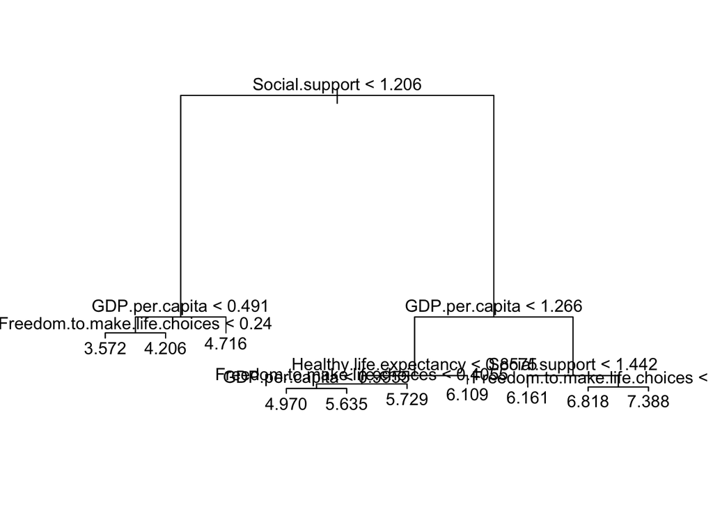

```r
tree.all = tree(Score~., data = dat1) #take account all factors
plot(tree.all)
text(tree.all,pretty = 0)
```

```r
tree.all
```

```
## node), split, n, deviance, yval
##       * denotes terminal node
##
##  1) root 156 192.1000 5.407
##    2) Social.support < 1.206 62  25.4700 4.385
##      4) GDP.per.capita < 0.491 29   8.8390 4.009
##        8) Freedom.to.make.life.choices < 0.24 9   1.8670 3.572 *
##        9) Freedom.to.make.life.choices > 0.24 20   4.4760 4.206 *
##      5) GDP.per.capita > 0.491 33   8.9220 4.716 *
##    3) Social.support > 1.206 94  59.1500 6.081
##      6) GDP.per.capita < 1.266 61  19.7900 5.677
##       12) Healthy.life.expectancy < 0.8575 45  12.9900 5.523
##         24) Freedom.to.make.life.choices < 0.4055 21   5.2930 5.287
##           48) GDP.per.capita < 0.9955 11   1.4550 4.970 *
##           49) GDP.per.capita > 0.9955 10   1.5220 5.635 *
##         25) Freedom.to.make.life.choices > 0.4055 24   5.5070 5.729 *
##       13) Healthy.life.expectancy > 0.8575 16   2.7450 6.109 *
##      7) GDP.per.capita > 1.266 33  10.9300 6.829
##       14) Social.support < 1.442 9   1.3150 6.161 *
##       15) Social.support > 1.442 24   4.1000 7.079
##         30) Freedom.to.make.life.choices < 0.5565 13   1.4320 6.818 *
##         31) Freedom.to.make.life.choices > 0.5565 11   0.7319 7.388 *
```

```r
yhat.tree.all = predict(tree.all, dat1)
yhat.tree.all
```

```
##        1        2        3        4        5        6        7        8
## 7.387909 7.387909 7.387909 7.387909 7.387909 7.387909 7.387909 7.387909
##        9       10       11       12       13       14       15       16
## 7.387909 6.817923 7.387909 6.108563 6.817923 6.817923 6.817923 6.817923
##       17       18       19       20       21       22       23       24
## 6.817923 6.817923 6.817923 6.817923 6.161222 7.387909 6.108563 6.817923
##       25       26       27       28       29       30       31       32
## 6.161222 6.108563 5.729458 6.161222 6.161222 6.817923 6.108563 5.635200
##       33       34       35       36       37       38       39       40
## 6.108563 6.817923 5.729458 6.817923 6.161222 6.108563 5.729458 6.108563
##       41       42       43       44       45       46       47       48
## 5.729458 5.635200 5.729458 6.108563 5.729458 5.729458 6.108563 5.729458
##       49       50       51       52       53       54       55       56
## 6.108563 6.108563 6.161222 5.729458 5.635200 6.161222 6.108563 5.729458
##       57       58       59       60       61       62       63       64
## 5.729458 6.161222 5.729458 5.729458 5.729458 5.635200 5.729458 6.108563
##       65       66       67       68       69       70       71       72
## 5.729458 6.108563 4.715758 5.635200 5.729458 5.635200 4.970273 5.729458
##       73       74       75       76       77       78       79       80
## 6.108563 4.715758 6.108563 6.161222 5.729458 4.970273 5.635200 4.715758
##       81       82       83       84       85       86       87       88
## 5.635200 4.715758 4.970273 4.970273 4.715758 5.729458 5.635200 4.715758
##       89       90       91       92       93       94       95       96
## 4.715758 4.715758 4.970273 4.715758 4.715758 5.729458 5.729458 4.715758
##       97       98       99      100      101      102      103      104
## 5.635200 4.715758 4.715758 5.729458 4.970273 4.206000 4.715758 4.715758
##      105      106      107      108      109      110      111      112
## 4.715758 4.970273 4.715758 4.970273 4.715758 4.970273 4.206000 4.206000
##      113      114      115      116      117      118      119      120
## 4.970273 4.206000 4.206000 4.715758 4.715758 4.206000 4.715758 4.206000
##      121      122      123      124      125      126      127      128
## 4.715758 4.715758 4.206000 4.715758 4.715758 4.715758 4.206000 4.206000
##      129      130      131      132      133      134      135      136
## 4.206000 5.729458 4.715758 3.571889 4.970273 4.206000 4.715758 4.206000
##      137      138      139      140      141      142      143      144
## 4.715758 4.715758 4.206000 4.715758 4.206000 3.571889 3.571889 4.206000
##      145      146      147      148      149      150      151      152
## 3.571889 4.206000 3.571889 4.715758 4.715758 4.206000 3.571889 4.206000
##      153      154      155      156
## 4.206000 3.571889 3.571889 3.571889
```

```r
MSE.tree.all = mean((dat1$Score-yhat.tree.all)^2)
MSE.tree.all
```

```
## [1] 0.1921395
```

MSE is 0.1921395

#### Prune the tree to get rid off some branches :

```r
prune.tree.all = prune.tree(tree.all)
prune.tree.all
```

```
## $size
## [1] 10  9  7  6  5  4  3  2  1
##
## $dev
## [1]  29.97376  31.90952  36.41899  38.91477  42.96284  48.47818  56.18379
## [8]  84.61726 192.05056
##
## $k
## [1]       -Inf   1.935768   2.254736   2.495774   4.048070   5.515344   7.705608
## [8]  28.433470 107.433296
##
## $method
## [1] "deviance"
##
## attr(,"class")
## [1] "prune"         "tree.sequence"
```

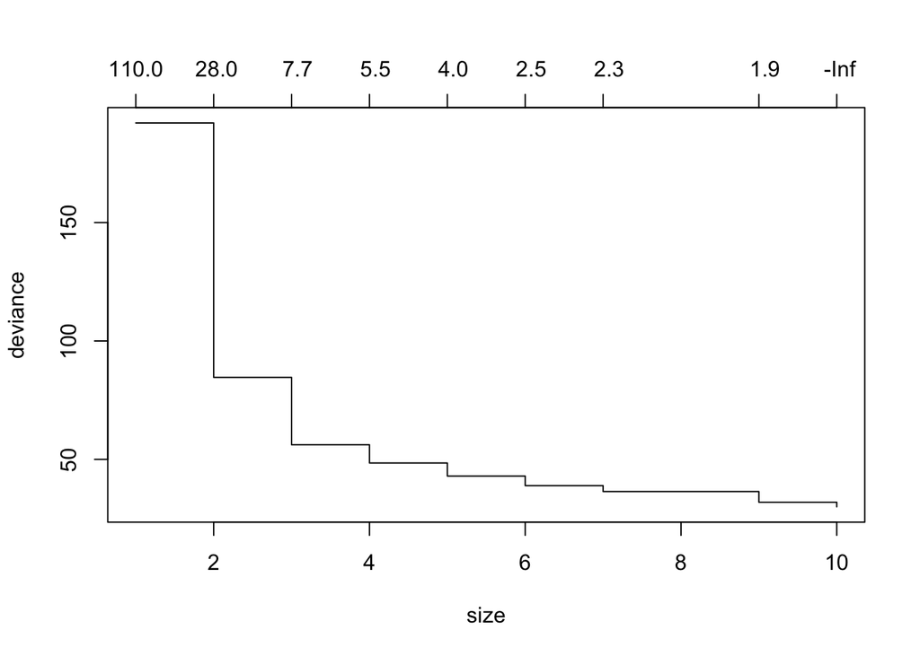

```r
plot(prune.tree.all)
```

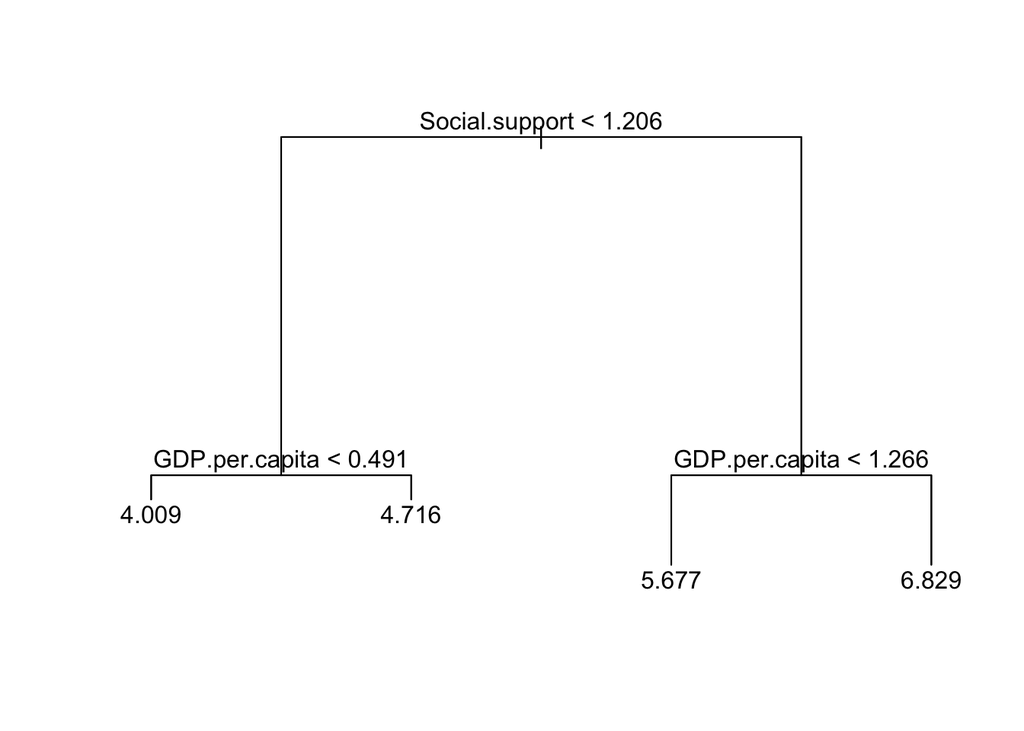

```r
prune.tree = prune.tree(tree.all,best = 4) # we only look 6 branch
plot(prune.tree)
text(prune.tree, pretty = 0)
```

```r
yhat.prune.tree = predict(prune.tree, dat1)
MSE.prune.tree  = mean((dat1$Score - yhat.prune.tree)^2)
MSE.prune.tree
```

```
## [1] 0.3107576
```

MSE.prune.tree in this case = 0.3107576 There is an increase in pruned tree, but easier to interpretation

#### Finding the best pruned tree using cross-validation on the training set:

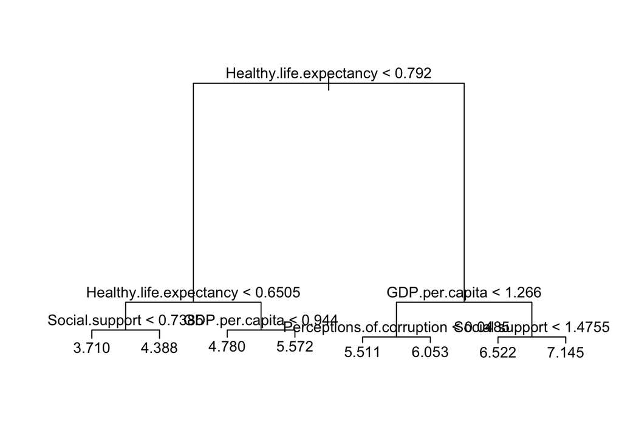

```r
set.seed(1)
tree.train = tree(Score~., data = dat.train)
plot(tree.train)
text(tree.train,pretty = 0)
```

```r
tree <- predict(tree.train, dat.valid)
mean((dat.valid$Score - tree)^2)
```

```
## [1] 0.47322
```

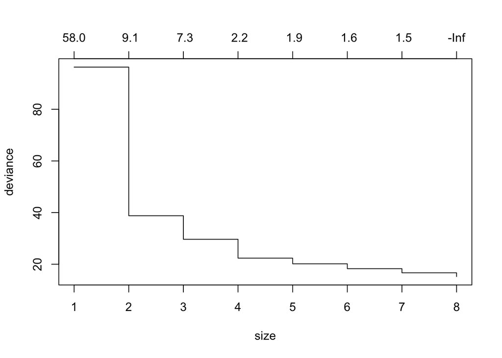

```r
#
prune.tree.train = prune.tree(tree.train)
plot(prune.tree.train)
```

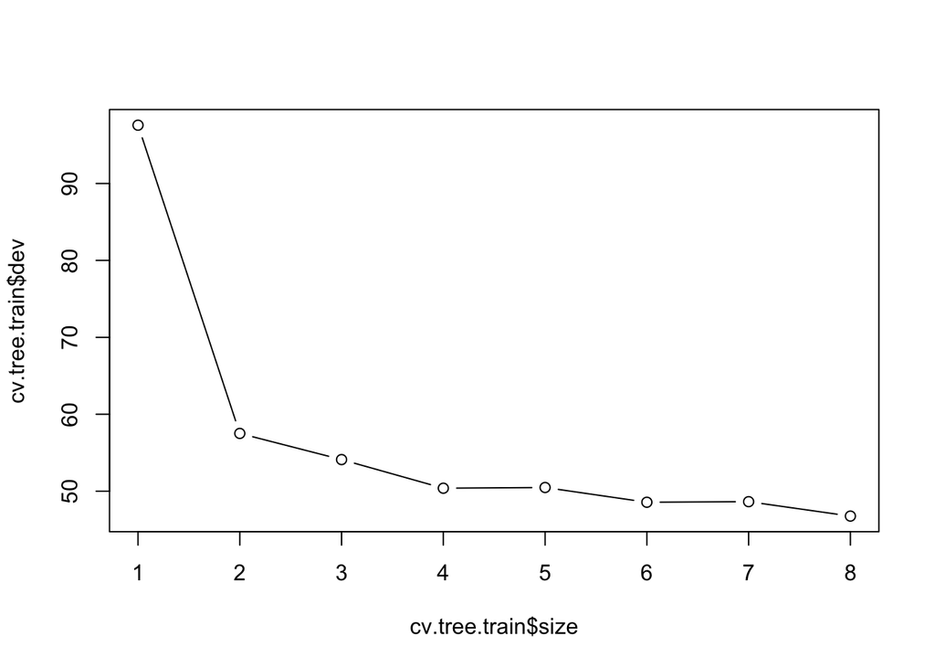

```r
#
cv.tree.train = cv.tree(tree.train)
plot(cv.tree.train$size,cv.tree.train$dev,type = "b")
```

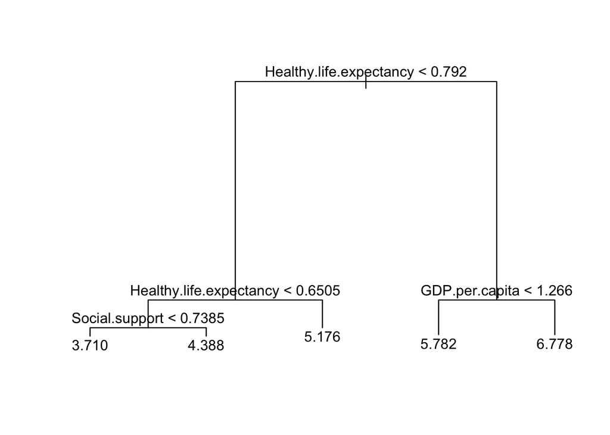

```r
#We will choose 5 branches.

prune.tree.5 = prune.tree(tree.train,best=5)
plot(prune.tree.5)
text(prune.tree.5,pretty = 0)
```

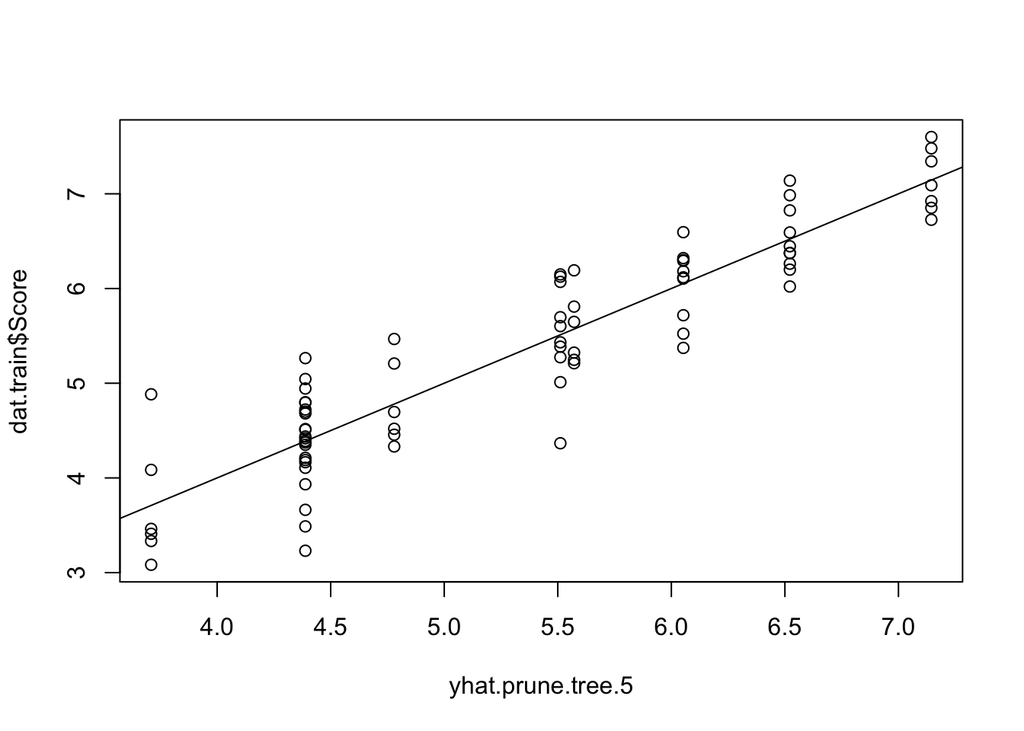

```r
#
yhat.prune.tree.5 = predict(tree.train,dat.train)
plot(yhat.prune.tree.5,dat.train$Score)
abline(0,1)
```

```r
MSE.prune.tree.5 = mean((dat.train$Score - yhat.prune.tree.5)^2)
MSE.prune.tree.5
```

```
## [1] 0.195074
```

```r
#the MSE to the test data set:
yhat.tree.valid = predict(tree.train,dat.valid)
MSE.prune.tree.5.valid = mean((dat.valid$Score - yhat.tree.valid)^2)
MSE.prune.tree.5.valid
```

```
## [1] 0.47322
```

#### Bagging

```r
set.seed(1)
bag.happiness = randomForest(Score~., data = dat1, subset = train,
                             mtry = 11,importance = TRUE)
bag.happiness
```

```
##
## Call:
##  randomForest(formula = Score ~ ., data = dat1, mtry = 11, importance = TRUE,      subset = train)
##                Type of random forest: regression
##                      Number of trees: 500
## No. of variables tried at each split: 6
##
##           Mean of squared residuals: 0.3344055
##                     % Var explained: 72.93
```

```r
importance(bag.happiness)
```

```
##                                 %IncMSE IncNodePurity
## GDP.per.capita               20.9539698     30.989430
## Social.support               13.7814449     20.783324
## Healthy.life.expectancy      21.4888365     30.262989
## Freedom.to.make.life.choices 10.8448485      5.517545
## Generosity                   -0.5548402      2.958512
## Perceptions.of.corruption     4.8664215      3.325306
```

```r
yhat.bag = predict(bag.happiness,dat.valid)
MSE.bag.test = mean((dat.valid$Score - yhat.bag)^2)
MSE.bag.test
```

```
## [1] 0.3154293
```

#### Generalized Boosted Regression Models

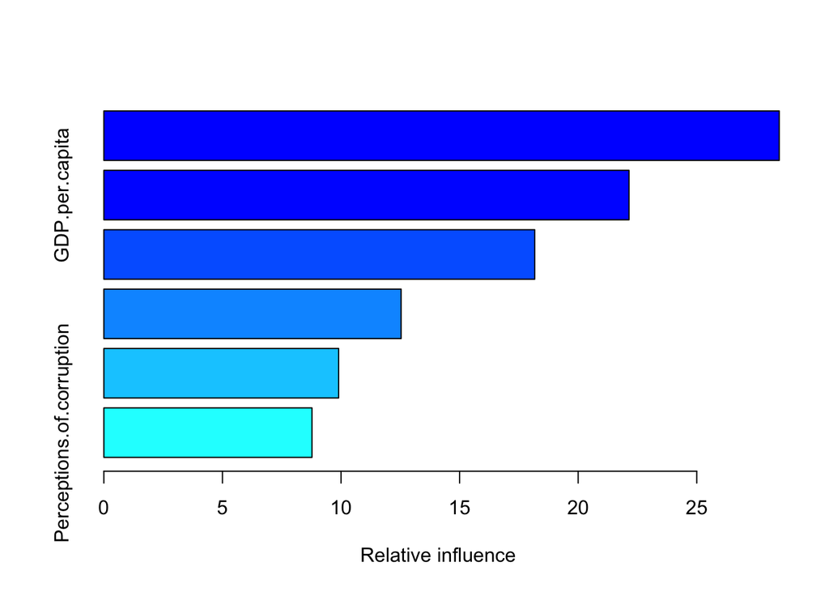

```
##                                                       var   rel.inf
## Healthy.life.expectancy           Healthy.life.expectancy 28.479138
## GDP.per.capita                             GDP.per.capita 22.143622
## Social.support                             Social.support 18.167860
## Freedom.to.make.life.choices Freedom.to.make.life.choices 12.534326
## Generosity                                     Generosity  9.899840
## Perceptions.of.corruption       Perceptions.of.corruption  8.775213
```

```r
boost <- gbm(Score~., data = dat.train, distribution = "gaussian",
             n.trees = 5000, interaction.depth = 4)
summary(boost)
```

```r
yhat.boost <- predict(boost, dat.valid, n.trees=5000)
MSE.boost <- mean((dat.valid$Score - yhat.boost)^2)
MSE.boost
```

```
## [1] 0.436671
```

# Part II:

## Look at the created indicator “high”, which stand for happier of not.

#### Create an indicator variable with logistic regression

```r
high<-ifelse(dat1$Score>5,1,0)    #we took the threshold of happiness score = 5, because the over all median is 5.3795
dat2 <- cbind(dat1,high)
names(dat2)
```

```
## [1] "Score"                        "GDP.per.capita"
## [3] "Social.support"               "Healthy.life.expectancy"
## [5] "Freedom.to.make.life.choices" "Generosity"
## [7] "Perceptions.of.corruption"    "high"
```

```r
dat2 <- dat2[,c(8,2:7)]
dat2$high <- as.factor(dat2$high)   #factorize the indicator variable "high"
logregall<-glm(high~.,data = dat2,family = "binomial")    #use regression to see which factor will make a country lay in Higher happiness group
summary(logregall)
```

```
##
## Call:
## glm(formula = high ~ ., family = "binomial", data = dat2)
##
## Deviance Residuals:
##     Min       1Q   Median       3Q      Max
## -2.2456  -0.1710   0.1026   0.3326   2.7375
##
## Coefficients:
##                              Estimate Std. Error z value    Pr(>|z|)
## (Intercept)                  -13.7025     2.6247  -5.221 0.000000178 ***
## GDP.per.capita                 3.0626     1.6700   1.834      0.0667 .
## Social.support                 5.0188     1.7341   2.894      0.0038 **
## Healthy.life.expectancy        5.3867     2.3804   2.263      0.0236 *
## Freedom.to.make.life.choices   5.0233     2.6593   1.889      0.0589 .
## Generosity                     0.6965     3.0886   0.226      0.8216
## Perceptions.of.corruption     -2.6016     6.0835  -0.428      0.6689
## ---
## Signif. codes:  0 '***' 0.001 '**' 0.01 '*' 0.05 '.' 0.1 ' ' 1
##
## (Dispersion parameter for binomial family taken to be 1)
##
##     Null deviance: 206.912  on 155  degrees of freedom
## Residual deviance:  72.576  on 149  degrees of freedom
## AIC: 86.576
##
## Number of Fisher Scoring iterations: 7
```

```r
# Null deviance: 206.912  on 155  degrees of freedom
# Residual deviance:  72.576  on 149  degrees of freedom
# AIC: 86.576
yhat.logregall<-predict(logregall,dat2,type="response")
yhat.logregall.class<-ifelse(yhat.logregall>0.5,1,0)
tab.logregall<-table(dat2$high,yhat.logregall.class,dnn=c("Actual","Predicted"))
tab.logregall    #check the prediction power
```

```
##       Predicted
## Actual  0  1
##      0 50  9
##      1  6 91
```

```r
mean(dat2$high != yhat.logregall.class)
```

```
## [1] 0.09615385
```

The error rate is 0.09615385(9.61%).